# Hands on Lesson: SPIA Assay

Elisa Bugani

7/5/2022

```r
rm(list=ls());verbose<-TRUE; options(max.print=1000);getOption("max.print")
```

```
## [1] 1000
```

To perform this set of tasks download the folder provided by Prof. Demichelis at:  
https://www.dropbox.com/s/9ej32psjur4gzyv/HandsOn_SPIA.zip?dl=0

This set of tasks is performed with the package ‘SPIAssay’, developed by Francesca Demichelis and Davide Prandi.  
The SNP Panel Identification Assay (SPIA) is a package that enables an accurate determination of cell line identity from the genotype of single nucleotide polymorphisms (SNPs). The SPIA test allows to discern when two cell lines are close enough to be called similar and when they are not (for further information see the documentation file ‘SPIAassay’ present in the folder).

```r
if(!require(SPIAssay)) install.packages("SPIAssay")
library(SPIAssay)

# Set working directory
setwd("C:/Users/elisa/Desktop/UNIVERSITAS/Trento/Anno_1/Human_Genomics/2_HandsOn_SPIA/HandsOn_SPIA")
```

Set the parameters for the probabilistic test:

```r
spia_parameters <- list(Pmm = 0.1, nsigma = 2, Pmm_nonM = 0.6, nsigma_nonM = 3, PercValidCall=0.7)
```

Parameters: - *Pmm*: SNP probability of mismatch in a matching population - *nsigma*: area limit for Pmm - *Pmm_nonM*: SNP probability of mismatch in a non matching population - *nsigma_nonM*: area limit for Pmm_nonM - *PercValidCall*: percentage of valid SNP calls to consider the test valid

Load genotype data:

```r
# Assuming that the genome file is located in the current directory
genotype_data <- read.table("SPIA_input_genotype.tsv", header = TRUE, sep = "\t", as.is = TRUE );

dim(genotype_data)
```

```
## [1] 2300   48
```

```r
head(genotype_data)
```

```
##            NA06984 NA06985 NA06986 NA06989 NA06994 NA07037 NA07048 NA07346
## rs61733845      NA       0       0       0       0       0       0       0
## rs1320571        0       0       0       0       0       0       0       0
## rs2760321        2       1       1      NA      NA       1       1       1
## rs2760320        0       0       0       0       0       0       0       0
## rs2296034        0       0       0       0       0       0       0       2
## rs11800462       0       0       0       0       0       0       0       0
##            NA10847 NA10851 NA11840 NA11843 NA11919 NA11992 NA11995 NA12004
## rs61733845      NA       0      NA      NA       0       0       0       0
## rs1320571       NA       0       0      NA       0       0       0       0
## rs2760321        1       1       1       1       1       2       1       2
## rs2760320        0       0       0       0       0       0       0       0
## rs2296034        0       2       0       0       0       0       0       0
## rs11800462       0       0       0       0       2       0       2       0
##            NA12006 NA12044 NA12155 NA12156 NA12249 NA12272 NA12273 NA12282
## rs61733845       0      NA       0      NA      NA      NA      NA      NA
## rs1320571        0       0       0       0      NA      NA      NA      NA
## rs2760321       NA       1       1       1      NA       1      NA      NA
## rs2760320        0       0       0       0       0       0       0       0
## rs2296034        0       0       2       0       0       0       0       0
## rs11800462       0       2       0       2       0       0       0      NA
##            NA12341 NA12342 NA12348 NA12400 NA12414 NA12489 NA12748 NA12750
## rs61733845      NA      NA       0      NA       0       0       0      NA
## rs1320571        0       0       0      NA       0       0       0       2
## rs2760321        1       1       1      NA       1       1       1       1
## rs2760320        0       2       0       2       0       0       0       0
## rs2296034        0       0       0       0       0       0       0       0
## rs11800462       0       2       0       0       0       2       2       0
##            NA12760 NA12761 NA12762 NA12763 NA12775 NA12812 NA12815 NA12829
## rs61733845       0      NA       0      NA       0      NA      NA       0
## rs1320571        0      NA       0      NA       0       2       0      NA
## rs2760321        2      NA       2      NA       2      NA      NA       1
## rs2760320        0       0       0       0       0       0       0       0
## rs2296034        0       0       0       0       2       0       0       2
## rs11800462       2       0       0       0       0       0       0       0
##            NA12830 NA12842 NA12843 NA12872 NA12873 NA12874 NA12889 NA12890
## rs61733845       0       2       0      NA      NA      NA      NA       0
## rs1320571        0       0       0       2       0       0       0       0
## rs2760321        1       1       1       1      NA       1       1       1
## rs2760320        0       0       0       0      NA       2       0       2
## rs2296034        0       0       0       0       0       0       0       0
## rs11800462       0      NA       0       2       0       0       2       0
```

The genotype file contains an array of 2300 SNPs represented by their SNP identifier beginning with ‘rs’ (rows) and their relative calls in a set of 48 samples (columns). Legend: SPIA uses 0 for AA, 1 for BB, 2 for AB and NA for NoCall.

We load a list of 143 selected SNPs with high MAF, so matching the requirements for the genetic test:

```r
# Load high MAF SNPs unique IDs
selected_snps <- read.delim("SPIA_selected_SNPs.txt", header = FALSE, sep = "\t", stringsAsFactors = FALSE)[,1]

length(selected_snps);
```

```
## [1] 143
```

```r
head(selected_snps);
```

```
## [1] "rs2296035" "rs785468"  "rs785467"  "rs835435"  "rs783036"  "rs1184626"
```

### TASK 1

Observe genetic distances among n individuals using 143, 100, 80, 60, 40, 20 high MAF SNPs.

Select genotype data based on SNP IDs:

```r
# Select only the rows with an ID matching the ones present in 'selected_snps' and all the columns related to those
genotype_data_selected <- genotype_data[selected_snps,]

dim(genotype_data_selected);
```

```
## [1] 143  48
```

Run the test using the function ‘SPIATest’ which computes the SPIA distance on a set of cell lines/samples and performs the associated probabilistic test. Here, the SPIATest is run on the previously selected genotype data with the parameters set at the beginning.

```r
SPIA_selected <-  SPIATest(x = genotype_data_selected, row.names = FALSE, test.param = spia_parameters)
```

```
## SPIA: start analysis:
```

```
## ....................
```

```
## SPIA: analysis completed.
```

Visualize pairwise distances among all samples with the function SPIAPlot that creates a summary graph of the SPIA test. With 48 samples, we will have a total number of combinations of: 48*47/2 = 1.128.

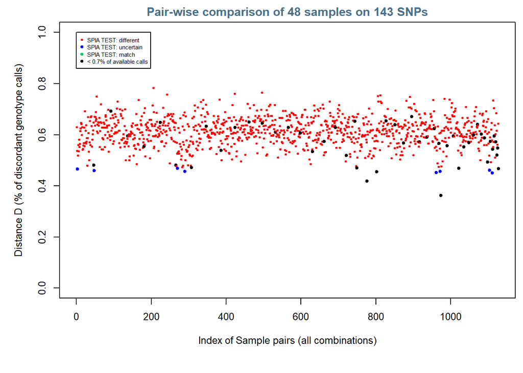

```r
SPIAPlot(SPIA_selected)
```

- The majority of the pairs were considered to be ‘different’ (red dots)
- A few were marked as ‘uncertain’ (blue dots) meaning that, according to the parameters used, it was not possible to produce a certain call (similar or different)
- Some pairs are represented in black since the percentage of available SNP calls was too low (< 0.7%) to consider the test valid (as set in the parameters at the beginning) Overall, we see an average distance of ~0.6 among all pairs.

We can check output matrix ‘SPIAresult’ present in the object ‘SPIA_selected’ to see more detailed information for each pair.

```r
SPIA_selected
```

```
## $SPIAresult
##         Cell_1    Cell_2    Distance  SPIA_Score  SNP_available Total_SNP
##    [1,] "NA06984" "NA06985" "0.62963" "Different" "135"         "143"
##    [2,] "NA06984" "NA06986" "0.53676" "Different" "136"         "143"
##    [3,] "NA06984" "NA06989" "0.46512" "Uncertain" "129"         "143"
##    [4,] "NA06984" "NA06994" "0.51938" "Different" "129"         "143"
##    [5,] "NA06984" "NA07037" "0.5597"  "Different" "134"         "143"
##    [6,] "NA06984" "NA07048" "0.53543" "Different" "127"         "143"
##    [7,] "NA06984" "NA07346" "0.58088" "Different" "136"         "143"
##    [8,] "NA06984" "NA10847" "0.55147" "Different" "136"         "143"
##    [9,] "NA06984" "NA10851" "0.56391" "Different" "133"         "143"
##   [10,] "NA06984" "NA11840" "0.61481" "Different" "135"         "143"
##   [11,] "NA06984" "NA11843" "0.625"   "Different" "136"         "143"
##   [12,] "NA06984" "NA11919" "0.64615" "Different" "130"         "143"
##   [13,] "NA06984" "NA11992" "0.64234" "Different" "137"         "143"
```

[output cut: 245 more lines]

```r
head(SPIA_selected["SPIAresult"])
```

```
## $SPIAresult
##         Cell_1    Cell_2    Distance  SPIA_Score  SNP_available Total_SNP
##    [1,] "NA06984" "NA06985" "0.62963" "Different" "135"         "143"
##    [2,] "NA06984" "NA06986" "0.53676" "Different" "136"         "143"
##    [3,] "NA06984" "NA06989" "0.46512" "Uncertain" "129"         "143"
##    [4,] "NA06984" "NA06994" "0.51938" "Different" "129"         "143"
##    [5,] "NA06984" "NA07037" "0.5597"  "Different" "134"         "143"
##    [6,] "NA06984" "NA07048" "0.53543" "Different" "127"         "143"
##    [7,] "NA06984" "NA07346" "0.58088" "Different" "136"         "143"
##    [8,] "NA06984" "NA10847" "0.55147" "Different" "136"         "143"
##    [9,] "NA06984" "NA10851" "0.56391" "Different" "133"         "143"
##   [10,] "NA06984" "NA11840" "0.61481" "Different" "135"         "143"
##   [11,] "NA06984" "NA11843" "0.625"   "Different" "136"         "143"
##   [12,] "NA06984" "NA11919" "0.64615" "Different" "130"         "143"
##   [13,] "NA06984" "NA11992" "0.64234" "Different" "137"         "143"
```

[output cut: 218 more lines]

Look at distances histogram (column 3 of SPIAresult:

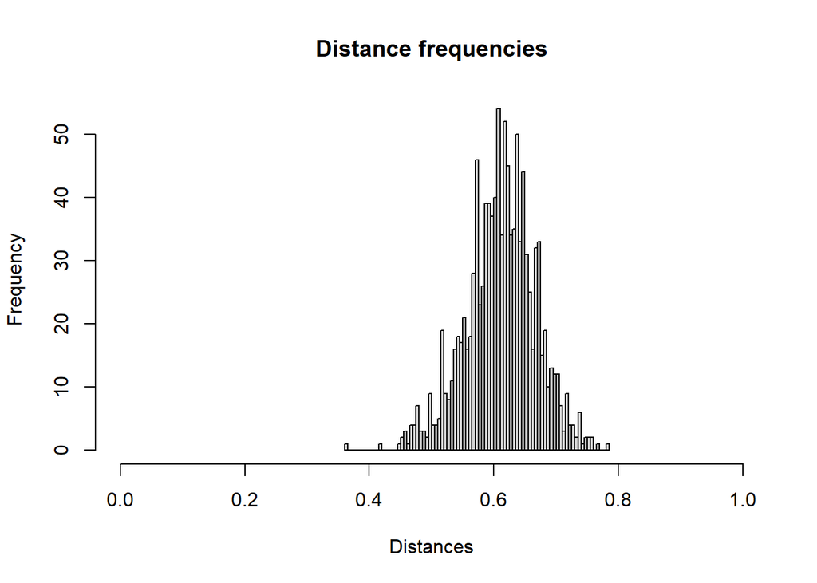

```r
hist(as.numeric(SPIA_selected$SPIAresult[,3]), breaks = 100, xlim=c(0,1), xlab = "Distances", main = "Distance frequencies")
```

Save output matrix:

```r
write.table(SPIA_selected["SPIAresult"], paste("output_","selected",".txt",sep=""), sep="\t", quote=FALSE, row.names=FALSE)
```

#### 100 SNPs

We repeat the operation with 100 selected SNPs. The 100 SNPs are randomly sampled from the 143 high MAF SNPs using ‘sample’ function and their indexes are stored in the variable ‘c100’.

```r
c100 <- sample(c(1:nrow(genotype_data_selected)), 100, replace = FALSE);
```

```r
# run test again selecting the c100 SNPs from 'genotype_data_selected'
SPIA_selected <-  SPIATest(x = genotype_data_selected[c100,], row.names = FALSE, test.param = spia_parameters)
```

```
## SPIA: start analysis:
```

```
## ....................
```

```
## SPIA: analysis completed.
```

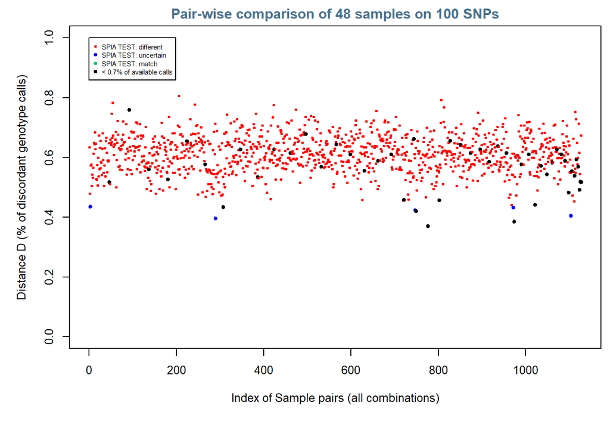

```r
SPIAPlot(SPIA_selected)
```

With 100 SNPs the output looks quite similar to the previous one. The average distance is still ~0.6 but there seems to be a slight increase in the standard deviation.  
The same thing will happen when decreasing more the number of selected SNPs.

```r
## check output matrix
head(SPIA_selected["SPIAresult"])
```

```
## $SPIAresult
##         Cell_1    Cell_2    Distance  SPIA_Score  SNP_available Total_SNP
##    [1,] "NA06984" "NA06985" "0.63441" "Different" "93"          "100"
##    [2,] "NA06984" "NA06986" "0.47872" "Different" "94"          "100"
##    [3,] "NA06984" "NA06989" "0.43478" "Uncertain" "92"          "100"
##    [4,] "NA06984" "NA06994" "0.57303" "Different" "89"          "100"
##    [5,] "NA06984" "NA07037" "0.57609" "Different" "92"          "100"
##    [6,] "NA06984" "NA07048" "0.50575" "Different" "87"          "100"
##    [7,] "NA06984" "NA07346" "0.54255" "Different" "94"          "100"
##    [8,] "NA06984" "NA10847" "0.53191" "Different" "94"          "100"
##    [9,] "NA06984" "NA10851" "0.56522" "Different" "92"          "100"
##   [10,] "NA06984" "NA11840" "0.6129"  "Different" "93"          "100"
##   [11,] "NA06984" "NA11843" "0.64894" "Different" "94"          "100"
##   [12,] "NA06984" "NA11919" "0.64444" "Different" "90"          "100"
##   [13,] "NA06984" "NA11992" "0.68421" "Different" "95"          "100"
```

[output cut: 218 more lines]

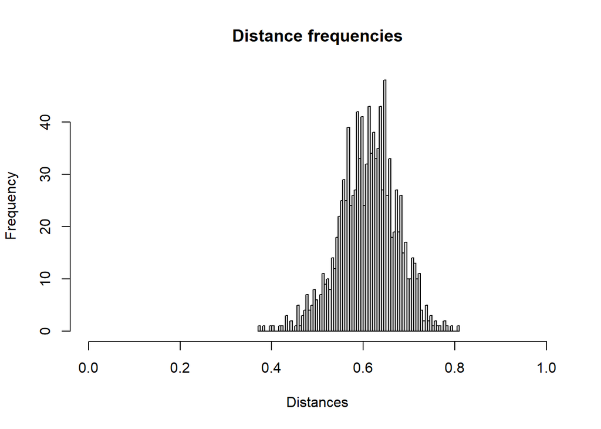

```r
## look at distances histogram
hist(as.numeric(SPIA_selected$SPIAresult[,3]), breaks = 100, xlim=c(0,1), xlab = "Distances", main = "Distance frequencies")
```

```r
## save output matrix
write.table(SPIA_selected["SPIAresult"], paste("output_", "100_", "selected",".txt",sep=""), sep="\t", quote=FALSE, row.names=FALSE)
```

#### 80 SNPs

```r
# subsampling of 80 high MAF SNPs
c80 <- sample(c(1:nrow(genotype_data_selected)), 80, replace = FALSE);
```

```r
# run test again
SPIA_selected <-  SPIATest(x = genotype_data_selected[c80,], row.names = FALSE, test.param = spia_parameters)
```

```
## SPIA: start analysis:
```

```
## ....................
```

```
## SPIA: analysis completed.
```

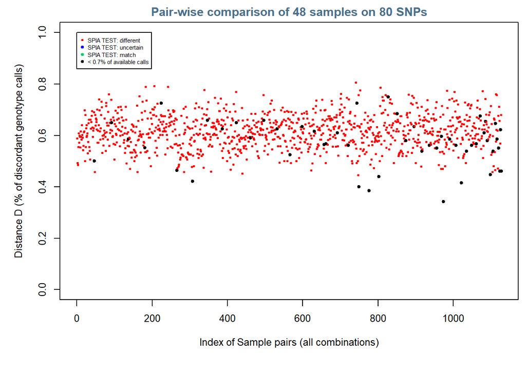

```r
SPIAPlot(SPIA_selected)
```

```r
## check output matrix
head(SPIA_selected["SPIAresult"]);
```

```
## $SPIAresult
##         Cell_1    Cell_2    Distance  SPIA_Score  SNP_available Total_SNP
##    [1,] "NA06984" "NA06985" "0.58904" "Different" "73"          "80"
##    [2,] "NA06984" "NA06986" "0.49333" "Different" "75"          "80"
##    [3,] "NA06984" "NA06989" "0.48571" "Different" "70"          "80"
##    [4,] "NA06984" "NA06994" "0.55556" "Different" "72"          "80"
##    [5,] "NA06984" "NA07037" "0.60811" "Different" "74"          "80"
##    [6,] "NA06984" "NA07048" "0.57143" "Different" "70"          "80"
##    [7,] "NA06984" "NA07346" "0.6"     "Different" "75"          "80"
##    [8,] "NA06984" "NA10847" "0.59459" "Different" "74"          "80"
##    [9,] "NA06984" "NA10851" "0.55405" "Different" "74"          "80"
##   [10,] "NA06984" "NA11840" "0.61644" "Different" "73"          "80"
##   [11,] "NA06984" "NA11843" "0.59459" "Different" "74"          "80"
##   [12,] "NA06984" "NA11919" "0.58333" "Different" "72"          "80"
##   [13,] "NA06984" "NA11992" "0.64"    "Different" "75"          "80"
```

[output cut: 218 more lines]

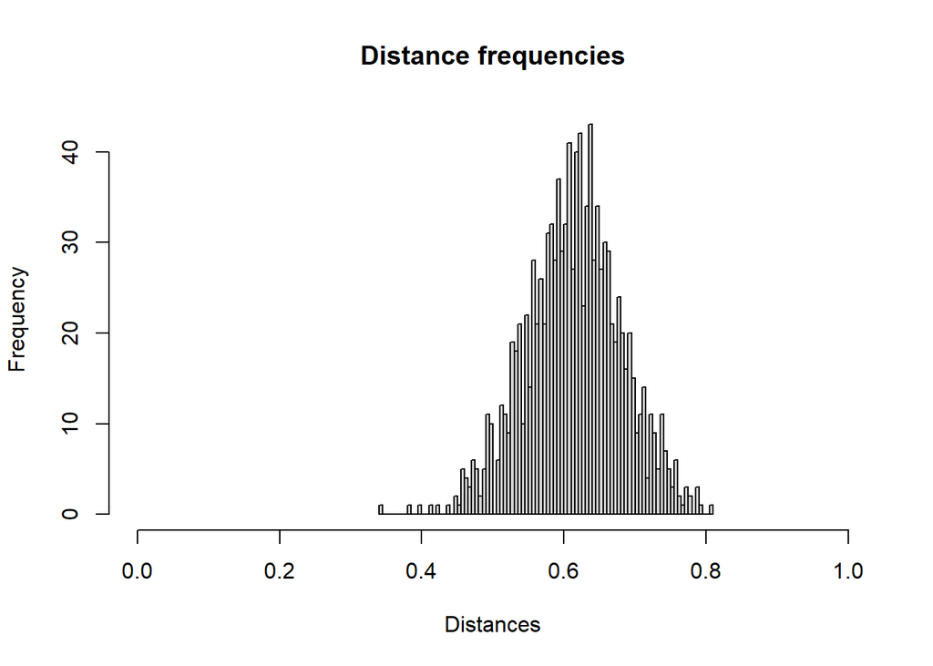

```r
# look at distances histogram
hist(as.numeric(SPIA_selected$SPIAresult[,3]), breaks = 100, xlim=c(0,1), xlab = "Distances", main = "Distance frequencies")
```

```r
## save output matrix
write.table(SPIA_selected["SPIAresult"], paste("output_", "80_", "selected",".txt",sep=""), sep="\t", quote=FALSE, row.names=FALSE)
```

#### 60 SNPs

```r
c60 <- sample(c(1:nrow(genotype_data_selected)), 60, replace = FALSE);
```

```r
# run test again
SPIA_selected <-  SPIATest(x = genotype_data_selected[c60,], row.names = FALSE, test.param = spia_parameters)
```

```
## SPIA: start analysis:
```

```
## ....................
```

```
## SPIA: analysis completed.
```

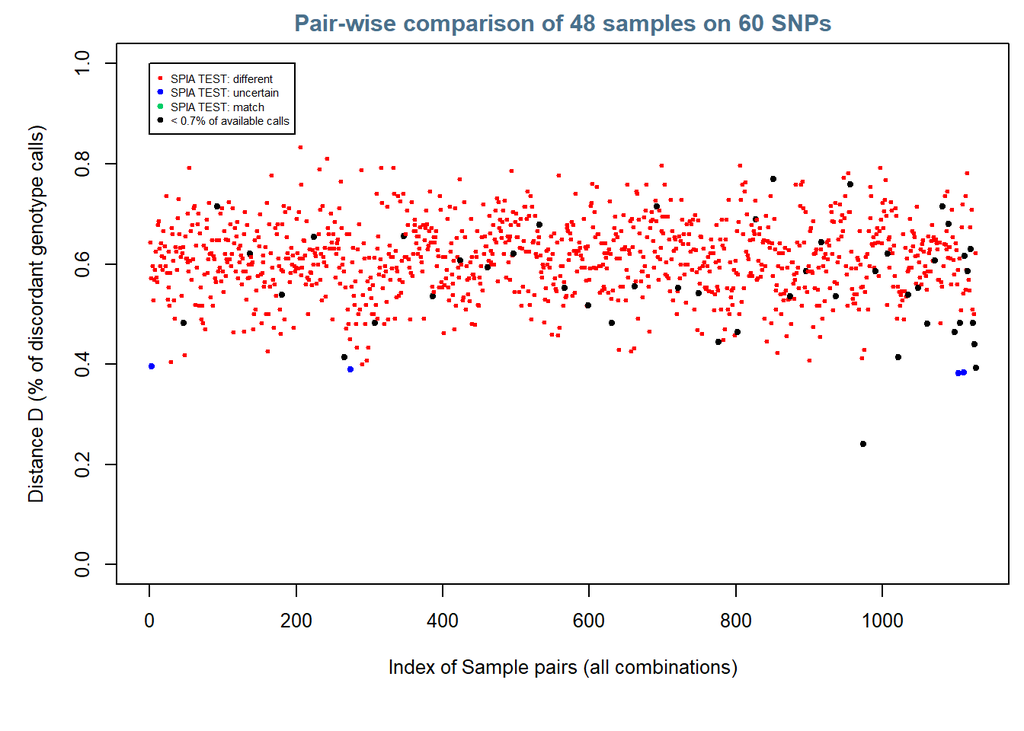

```r
SPIAPlot(SPIA_selected)
```

```r
## check output matrix
head(SPIA_selected["SPIAresult"]);
```

```
## $SPIAresult
##         Cell_1    Cell_2    Distance  SPIA_Score  SNP_available Total_SNP
##    [1,] "NA06984" "NA06985" "0.64286" "Different" "56"          "60"
##    [2,] "NA06984" "NA06986" "0.57143" "Different" "56"          "60"
##    [3,] "NA06984" "NA06989" "0.39623" "Uncertain" "53"          "60"
##    [4,] "NA06984" "NA06994" "0.59615" "Different" "52"          "60"
##    [5,] "NA06984" "NA07037" "0.52727" "Different" "55"          "60"
##    [6,] "NA06984" "NA07048" "0.56863" "Different" "51"          "60"
##    [7,] "NA06984" "NA07346" "0.58929" "Different" "56"          "60"
##    [8,] "NA06984" "NA10847" "0.625"   "Different" "56"          "60"
##    [9,] "NA06984" "NA10851" "0.57407" "Different" "54"          "60"
##   [10,] "NA06984" "NA11840" "0.56364" "Different" "55"          "60"
##   [11,] "NA06984" "NA11843" "0.67857" "Different" "56"          "60"
##   [12,] "NA06984" "NA11919" "0.68519" "Different" "54"          "60"
##   [13,] "NA06984" "NA11992" "0.63158" "Different" "57"          "60"
```

[output cut: 218 more lines]

```r
## look at distances histogram
hist(as.numeric(SPIA_selected$SPIAresult[,3]), breaks = 100, xlim=c(0,1), xlab = "Distances", main = "Distance frequencies")
```

[output not shown]

```r
## save output matrix
write.table(SPIA_selected["SPIAresult"], paste("output_", "60_", "selected",".txt",sep=""), sep="\t", quote=FALSE, row.names=FALSE)
```

#### 40 SNPs

```r
c40 <- sample(c(1:nrow(genotype_data_selected)), 40, replace = FALSE);
```

```r
# run test again
# SPIA_selected <-  SPIATest(x = genotype_data_selected[c40,], row.names = FALSE, test.param = spia_parameters)

# SPIAPlot(SPIA_selected)
```

Running the test with 40 or less SNPs might produce an error. This is due to the fact that SNPs are selected randomly and some combinations of them might not allow to perform the test. If so, run the test again.

```r
## look at distances histogram
hist(as.numeric(SPIA_selected$SPIAresult[,3]), breaks = 100, xlim=c(0,1), xlab = "Distances", main = "Distance frequencies")
```

[output not shown]

```r
## save output matrix
write.table(SPIA_selected["SPIAresult"], paste("output_", "40_", "selected",".txt",sep=""), sep="\t", quote=FALSE, row.names=FALSE)
```

#### 20 SNPs

```r
c20 <- sample(c(1:nrow(genotype_data_selected)), 20, replace = FALSE);
```

```r
# run test again
# SPIA_selected <-  SPIATest(x = genotype_data_selected[c20,], row.names = FALSE, test.param = spia_parameters)

# SPIAPlot(SPIA_selected)
```

```r
## look at distances histogram
hist(as.numeric(SPIA_selected$SPIAresult[,3]), breaks = 100, xlim=c(0,1), xlab = "Distances", main = "Distance frequencies")
```

[output not shown]

```r
## save output matrix
write.table(SPIA_selected["SPIAresult"], paste("output_", "20_", "selected",".txt",sep=""), sep="\t", quote=FALSE, row.names=FALSE)
```

### TASK 2

Observe genetic distances among m individuals using 100 from unselected SNPs

```r
# before we see what happens using all SNPs
SPIA_all <-  SPIATest(x = genotype_data, row.names = F, test.param = spia_parameters)
```

```
## SPIA: start analysis:
```

```
## ....................
```

```
## SPIA: analysis completed.
```

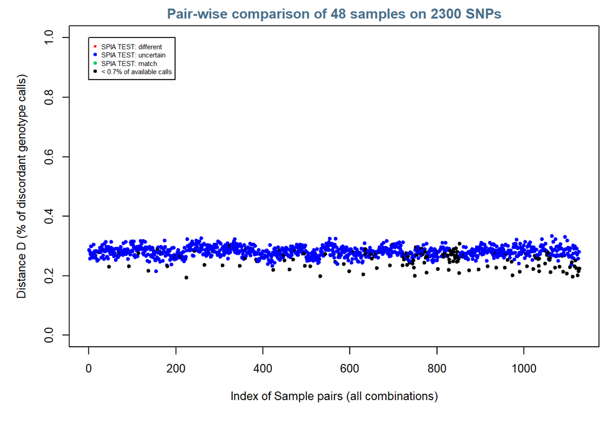

```r
SPIAPlot(SPIA_all)
```

Using all available SNPs leads to have many uncertain calls, a lower aberage distance (~0.2/0.3) and a lower standard deviation.

```r
# Now with 100 unselected SNPs
c100 <- sample(c(1:nrow(genotype_data)), 100, replace = FALSE)

genotype_data_random <- genotype_data[c100,]
```

```r
# run test
SPIA_random <-  SPIATest(x = genotype_data_random, row.names = F, test.param = spia_parameters)
```

```
## SPIA: start analysis:
```

```
## ....................
```

```
## SPIA: analysis completed.
```

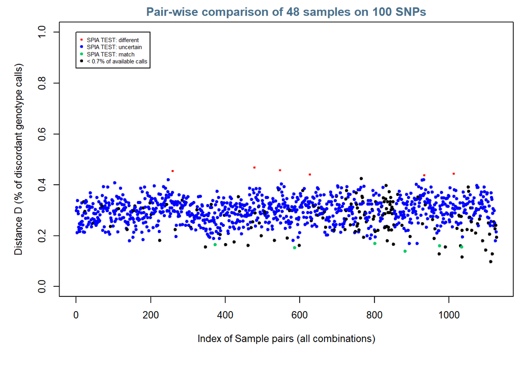

```r
SPIAPlot(SPIA_random)
```

The average looks more centered around 0.3, way lower than the one found with 100 selected SNPs, and the standard deviation has increased. The majority of outputs are still ‘uncertain’ indicating that with unselected SNPs it is more difficult to perform accurate genetic testing.

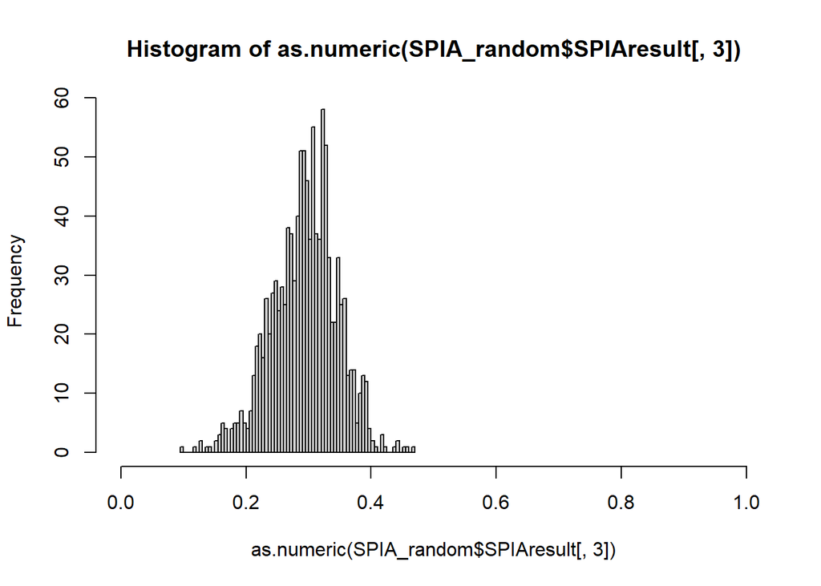

```r
hist(as.numeric(SPIA_random$SPIAresult[,3]), breaks = 100, xlim=c(0,1))
```

### TASK 3

Observe genetic distances among samples that include j pairs (normal and tumor DNA).

```r
## load somatic data
somatic_data <- read.table("SPIA_somatic_genotype.tsv", header = TRUE, sep = "\t", as.is = TRUE );

dim(somatic_data);
```

```
## [1] 334   7
```

There are 334 SNPs for 7 samples.

```r
head(somatic_data)
```

```
##            Sample_1_1 Sample_1_2 Sample_2_1 Sample_2_2 Sample_2_3 Sample_2_4
## rs3013105           1          1          0          0          0          0
## rs872222           NA          0          0          0          0          0
## rs2076595           0          0          2          2          2          0
## rs11203367          0          0          0          0          0          0
## rs2296035           0          0          1          2          2          2
## rs1142057          NA         NA         NA         NA         NA         NA
##            Sample_2_5
## rs3013105           0
## rs872222            0
## rs2076595           2
## rs11203367          0
## rs2296035           1
## rs1142057          NA
```

```r
# SPIA test with all SNPs
SPIA_somatic <-  SPIATest(x = somatic_data, row.names = F, test.param = spia_parameters)
```

```
## SPIA: start analysis:
```

```
## ...........
```

```
## SPIA: analysis completed.
```

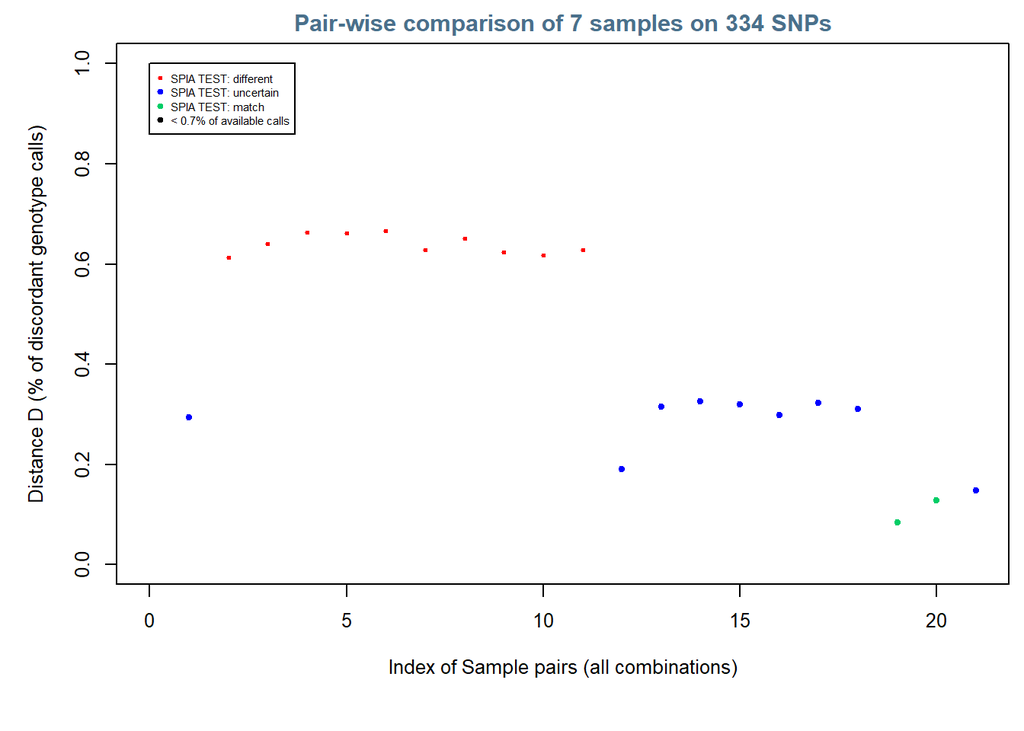

```r
SPIAPlot(SPIA_somatic)
```

From the plot we see that: - Some pairs were marked as ‘match’ indicating that the two samples probably belong to the same individual. - Some others were marked as uncertain. - Whereas 10 pairs were marked as ‘different’, since their level of distance is compatible with the option of the samples coming from different individuals.

To understand which samples might represent tumor tissue one thing that we could do is to look at the output matrix:

```r
head(SPIA_somatic["SPIAresult"])
```

```
## $SPIAresult
##       Cell_1       Cell_2       Distance   SPIA_Score  SNP_available Total_SNP
##  [1,] "Sample_1_1" "Sample_1_2" "0.29352"  "Uncertain" "293"         "334"
##  [2,] "Sample_1_1" "Sample_2_1" "0.61333"  "Different" "300"         "334"
##  [3,] "Sample_1_1" "Sample_2_2" "0.64026"  "Different" "303"         "334"
##  [4,] "Sample_1_1" "Sample_2_3" "0.6633"   "Different" "297"         "334"
##  [5,] "Sample_1_1" "Sample_2_4" "0.66216"  "Different" "296"         "334"
##  [6,] "Sample_1_1" "Sample_2_5" "0.66553"  "Different" "293"         "334"
##  [7,] "Sample_1_2" "Sample_2_1" "0.62838"  "Different" "296"         "334"
##  [8,] "Sample_1_2" "Sample_2_2" "0.65101"  "Different" "298"         "334"
##  [9,] "Sample_1_2" "Sample_2_3" "0.62373"  "Different" "295"         "334"
## [10,] "Sample_1_2" "Sample_2_4" "0.61824"  "Different" "296"         "334"
## [11,] "Sample_1_2" "Sample_2_5" "0.62759"  "Different" "290"         "334"
## [12,] "Sample_2_1" "Sample_2_2" "0.19079"  "Uncertain" "304"         "334"
## [13,] "Sample_2_1" "Sample_2_3" "0.31457"  "Uncertain" "302"         "334"
```

[output cut: 52 more lines]

By looking at this output one can try to understand if the mismatches are compatible with important genomic disorders, or many deletions causing loss of heterozygosity which are compatible with a tumor sample.

```r
# save SPIAresult
write.table(SPIA_somatic["SPIAresult"], paste("output_","somatic",".txt",sep=""), sep="\t", quote=FALSE, row.names=FALSE)
```

### TASK 4

Change confidence m in one of previous Tasks. Set parameters for high MAF SNPs, exploring different values for Pmm, Pmm_nonM, nsigma, nsigma_nonM (one at the time).

```r
# here we changed Pmm from 0.1 to 0.2
spia_parameters <- list(Pmm = 0.2, nsigma = 2, Pmm_nonM = 0.6, nsigma_nonM = 3, PercValidCall=0.7)
```

Task 1 - 100 SNPs.

```r
c100 <- sample(c(1:nrow(genotype_data_selected)), 100, replace = FALSE);
```

```r
# run test again selecting the c100 SNPs from 'genotype_data_selected'
SPIA_selected <-  SPIATest(x = genotype_data_selected[c100,], row.names = FALSE, test.param = spia_parameters)
```

```
## SPIA: start analysis:
```

```
## ....................
```

```
## SPIA: analysis completed.
```

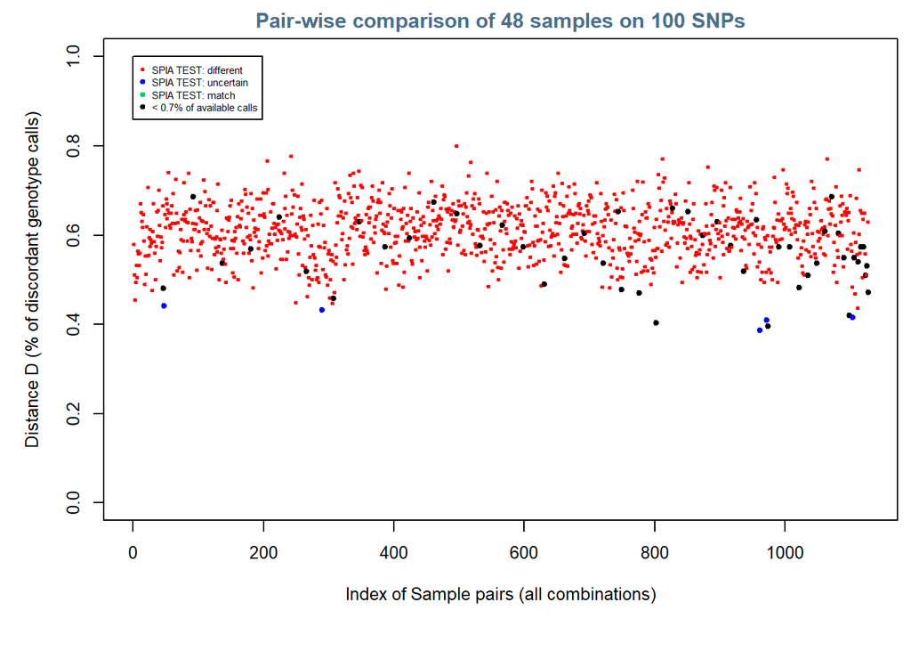

```r
SPIAPlot(SPIA_selected)
```

```r
## check output matrix
head(SPIA_selected["SPIAresult"])
```

```
## $SPIAresult
##         Cell_1    Cell_2    Distance  SPIA_Score  SNP_available Total_SNP
##    [1,] "NA06984" "NA06985" "0.57895" "Different" "95"          "100"
##    [2,] "NA06984" "NA06986" "0.51064" "Different" "94"          "100"
##    [3,] "NA06984" "NA06989" "0.45556" "Different" "90"          "100"
##    [4,] "NA06984" "NA06994" "0.49438" "Different" "89"          "100"
##    [5,] "NA06984" "NA07037" "0.53261" "Different" "92"          "100"
##    [6,] "NA06984" "NA07048" "0.50575" "Different" "87"          "100"
##    [7,] "NA06984" "NA07346" "0.56383" "Different" "94"          "100"
##    [8,] "NA06984" "NA10847" "0.55789" "Different" "95"          "100"
##    [9,] "NA06984" "NA10851" "0.53261" "Different" "92"          "100"
##   [10,] "NA06984" "NA11840" "0.55914" "Different" "93"          "100"
##   [11,] "NA06984" "NA11843" "0.67021" "Different" "94"          "100"
##   [12,] "NA06984" "NA11919" "0.65169" "Different" "89"          "100"
##   [13,] "NA06984" "NA11992" "0.63158" "Different" "95"          "100"
```

[output cut: 218 more lines]

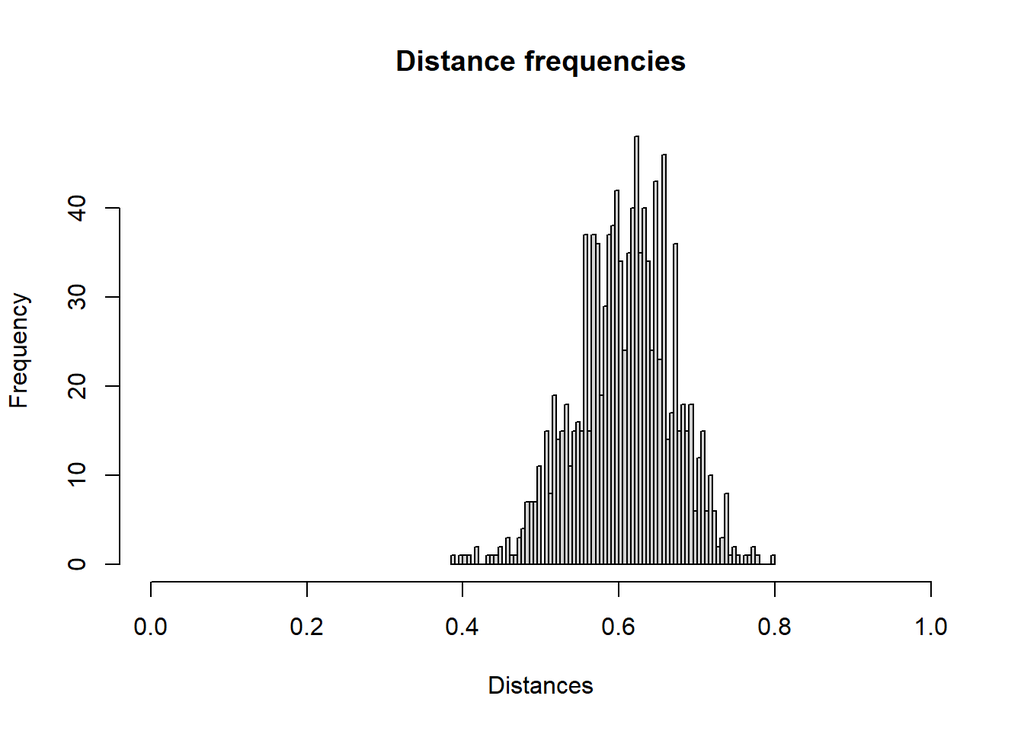

```r
## look at distances histogram
hist(as.numeric(SPIA_selected$SPIAresult[,3]), breaks = 100, xlim=c(0,1), xlab = "Distances", main = "Distance frequencies")
```

Task 1 - 80 SNPs.

```r
# subsampling of 80 high MAF SNPs
c80 <- sample(c(1:nrow(genotype_data_selected)), 80, replace = FALSE);
```

```r
# run test again
SPIA_selected <-  SPIATest(x = genotype_data_selected[c80,], row.names = FALSE, test.param = spia_parameters)
```

```
## SPIA: start analysis:
```

```
## ....................
```

```
## SPIA: analysis completed.
```

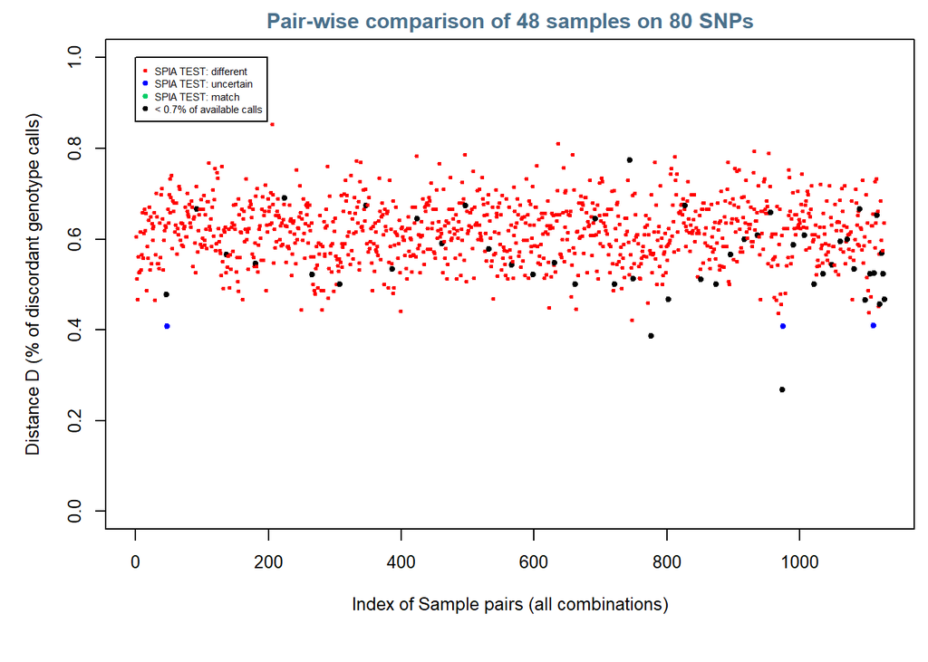

```r
SPIAPlot(SPIA_selected)
```

```r
## check output matrix
head(SPIA_selected["SPIAresult"]);
```

```
## $SPIAresult
##         Cell_1    Cell_2    Distance  SPIA_Score  SNP_available Total_SNP
##    [1,] "NA06984" "NA06985" "0.60526" "Different" "76"          "80"
##    [2,] "NA06984" "NA06986" "0.51282" "Different" "78"          "80"
##    [3,] "NA06984" "NA06989" "0.46667" "Different" "75"          "80"
##    [4,] "NA06984" "NA06994" "0.56164" "Different" "73"          "80"
##    [5,] "NA06984" "NA07037" "0.52632" "Different" "76"          "80"
##    [6,] "NA06984" "NA07048" "0.52778" "Different" "72"          "80"
##    [7,] "NA06984" "NA07346" "0.61538" "Different" "78"          "80"
##    [8,] "NA06984" "NA10847" "0.53247" "Different" "77"          "80"
##    [9,] "NA06984" "NA10851" "0.56579" "Different" "76"          "80"
##   [10,] "NA06984" "NA11840" "0.65789" "Different" "76"          "80"
##   [11,] "NA06984" "NA11843" "0.55844" "Different" "77"          "80"
##   [12,] "NA06984" "NA11919" "0.61333" "Different" "75"          "80"
##   [13,] "NA06984" "NA11992" "0.66667" "Different" "78"          "80"
```

[output cut: 218 more lines]

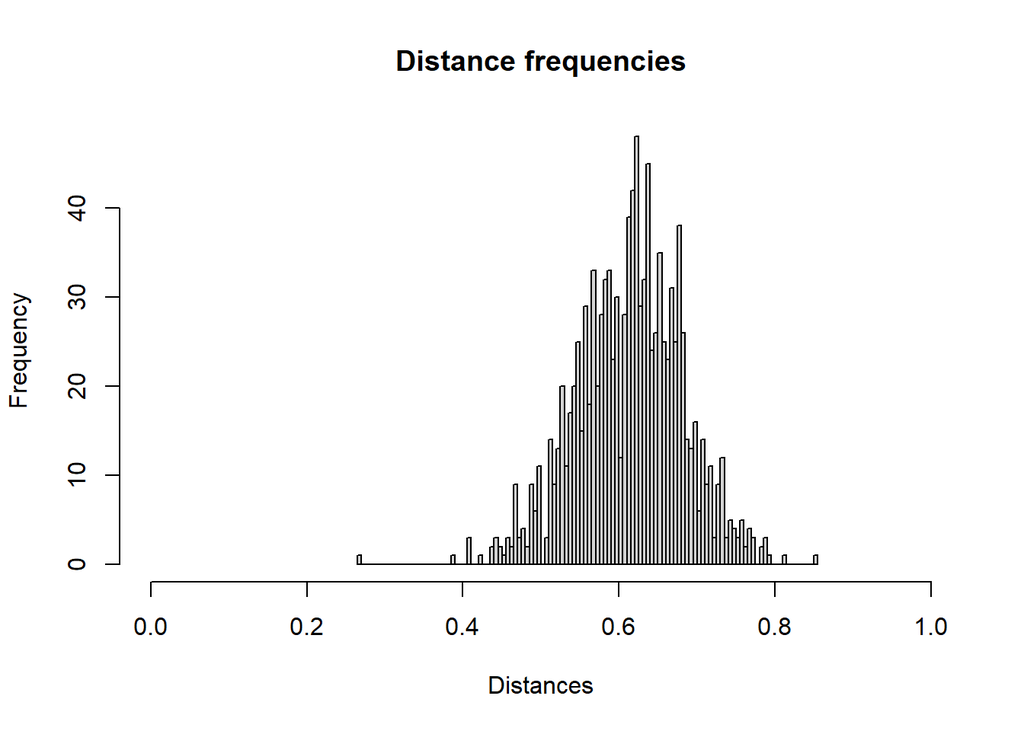

```r
# look at distances histogram
hist(as.numeric(SPIA_selected$SPIAresult[,3]), breaks = 100, xlim=c(0,1), xlab = "Distances", main = "Distance frequencies")
```

#### Additional:

How MAF is computed for a SNP across x individuals for which you have a genotype?

Example: 5 people Genotype: AA, AA, AB, AB, AA

How to determine MAF? Denominator is the number of alleles, here 5*2 = 10. Minor allele (less represented) = B, represented 2 times.

MAF = minor allele / total alleles = 2 / 10 = 0.2 = 20%

By looking at the input table we can see that many SNPs have a very low MAF. whereas the table with the selected SNPs will contain SNPs with a higher MAF.